# ESM 206 Lab 2 Part 1

Wrangling continued, pivot_longer(), ggplot2 customization

Allison Horst

11 October, 2020

## Lab 2 Part 1 objectives:

- Project management (subfolder structure & `here`)
- Continue meeting R Markdown
- More data wrangling
- Customization in ggplot2
- `pivot_longer` to gather data

## Packages required:

- tidyverse
- janitor

### 1. Lab set-up & project management:

- Create a new project (within your ESM 206 labs folder)
- Add subfolders `data`, `img`, `src`
- Copy and paste the ca_agriculture.csv file into the project `data` folder
- In RStudio, create a new RMarkdown doc (.Rmd). Save to the `src` folder

## 2. A couple more R Markdown tips

1. URL

Add a functional URL by just copying & pasting it: https://www.ucsb.edu/

Or add linked text [like this](https://www.ucsb.edu/).

2. Superscripts / subscripts

Add superscripts with two ^: like<sup>this</sup>

Or subscripts with two ~: like<sub>this</sub>

3. Add image from a URL
- Find an image online (for more octocats - the GitHub mascot- visit https://octodex.github.com/)
- Right click > Copy image location
- Paste the image location into the parentheses in this format:

`![](paste_image_location_here.png)`

For example:

[figure not shown]

But ask yourself: how does that break? What might be a safer and more robust way to include an image?

## 3. Easier file paths with `here()`

Today we’ll use information from California crop production from 2014.

We want to read in the ca_agriculture.csv data. But unlike last week, this file isn’t directly in our project *root* (top level of the project folder) - it is in a subfolder called `data`. We need an easy way to point R into that folder to find the file we want.

Remember: when working in projects, the working directory **is** the project folder. You can also find what the working directory is by running `here()` in the Console. Try it out! Notice it’s your R Project folder.

First, open the CSV in Excel or other spreadsheet software (outside of R, open the file & it will open in Excel if you have it). Make sure to take a look at the data after you read them in.

```r
# Read in the ca_agriculture.csv file

ca_ag <- read_csv(here("lab_2","data","ca_agriculture.csv")) %>%
  clean_names()
```

## 4. More `dplyr::filter()` examples

1. Keep data from counties “Kern” OR “Inyo” OR “Mono”

Use `%in%` to look for multiple acceptable matches.

```r
ex_a <- ca_ag %>%
  filter(county %in% c("Kern", "Inyo", "Mono"))
```

2. Keep data for all counties EXCEPT Merced

Use `!=` to say “DOES NOT MATCH”:

```r
ex_b <- ca_ag %>%
  filter(county != "Merced")
```

**Tip:** Use the `unique()` function to check with distinct groups remain in a variable

3. Keep observations where crop is “GOATS MILK” and county is “Humboldt”

```r
ex_c <- ca_ag %>%
  filter(crop_name == "GOATS MILK", county == "Humboldt")
```

4. Keep observations where crop is “GRAPES WINE” **or** harvest acres is greater than 1,000,000:

```r
ex_d <- ca_ag %>%
  filter(crop_name == "GRAPES WINE" | harvest_acres > 1e6)
```

## 5. `group_by()` + `summarize()` for tables of summary statistics

We often want to find summary statistics (e.g. mean, standard deviation, max, min, etc.) within *groups* for our data. For example, we may want to find the total *value* of crops by *county* for California in 2014. But it would be really tedious to make a different subset for each county, then find those statistics.

Instead, we will use the powerful combination of `dplyr::group_by()` and `summarize()` to:

- Recognize distinct groups within a variable
- Apply a function to each *group*
- Return the outcomes in a nice table

It is awesome. You should plan on using this all the time (if you’re an Excel wizard, this is your replacement for pivot tables).

We will pipe them together in a single sequences.

1. Create a summary table of the total sum of *value* by *county* for “GRAPES WINE”.

```r
ca_grapes <- ca_ag %>%
  filter(crop_name == "GRAPES WINE") %>%
  group_by(county) %>%
  summarize(
    total_value_usd = sum(value)
  ) %>%
  arrange(-total_value_usd) %>% # Arrange sorts things in order
  filter(county != "State Total") %>%  # Get rid of the summary value
  head(10) # Head only keeps the top 'x' lines
```

2. Another example: find the total yield (tons) by county for any crops containing the string “LETTUCE”

```r
ca_lettuce <- ca_ag %>%
  filter(str_detect(crop_name, "LETTUCE")) %>%
  filter(!county %in% c("State Total","Sum of Others")) %>%
  group_by(county) %>%
  summarize(production_acres = sum(production, na.rm = TRUE),
            harvested_acres = sum(harvest_acres, na.rm = TRUE))
```

## 5. Customizing ggplot graphs

In the Week 1 Assignment, you made 4 basic ggplot graphs. Throughout the rest of the quarter, we will emphasize data visualization as a critical part of science communication.

Here, let’s cover several useful ways to customize our ggplot graphs!

[figure not shown]

```r
ggplot(data = ca_lettuce,
       aes(x = fct_reorder(county, harvested_acres),
                                    y = harvested_acres)) +
  geom_col(fill = "gray70") +
  labs(x = "California County",
       y = "Harvested land (acres)",
       title = "California's top 10 lettuce producing counties (2014)") +
  coord_flip() +
  theme_minimal()
```

Another example: jitterplot

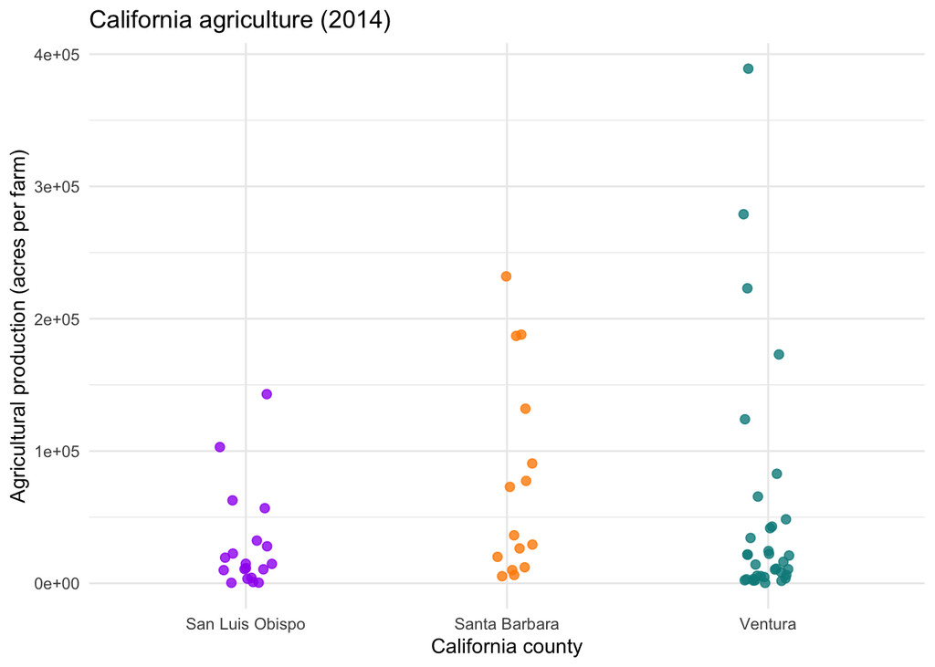

```r
cc_ag <- ca_ag %>%
  filter(county %in% c("San Luis Obispo", "Santa Barbara", "Ventura"))

ggplot(data = cc_ag, aes(x = county, y = production)) +
  geom_jitter(width = 0.1,
              alpha = 0.8,
              size = 2,
              aes(color = county),
              show.legend = FALSE) +
  theme_minimal() +
  scale_color_manual(values = c("purple","darkorange","cyan4")) +
  labs(x = "California county",
       y = "Agricultural production (acres per farm)",
       title = "California agriculture (2014)")
```